# Data Visualization

Now lets see what were the reasons why subjects were arrested and of which race.

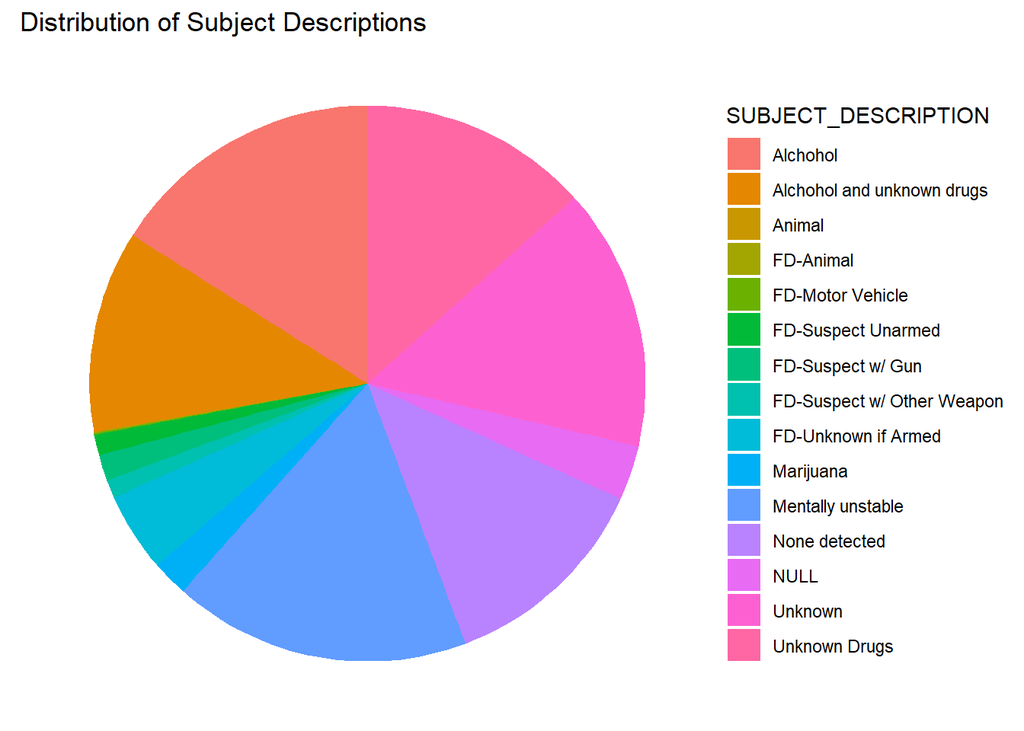

```r
subject_counts <- table(dvDataFrame$SUBJECT_DESCRIPTION)
# Convert the table to a data frame
subject_counts_df <- data.frame(SUBJECT_DESCRIPTION = names(subject_counts),
                                count = as.vector(subject_counts))
# Create a pie chart
 ggplot(subject_counts_df, aes(x = "", fill = SUBJECT_DESCRIPTION, y = count))  +
  coord_polar("y", start=0)+
  geom_bar(stat = "identity", width = 1)+
  labs(title = "Distribution of Subject Descriptions") +
  theme_void()
```

Let us explore the relationship between the demographic variable of subject race and the categorical variable of subject description.

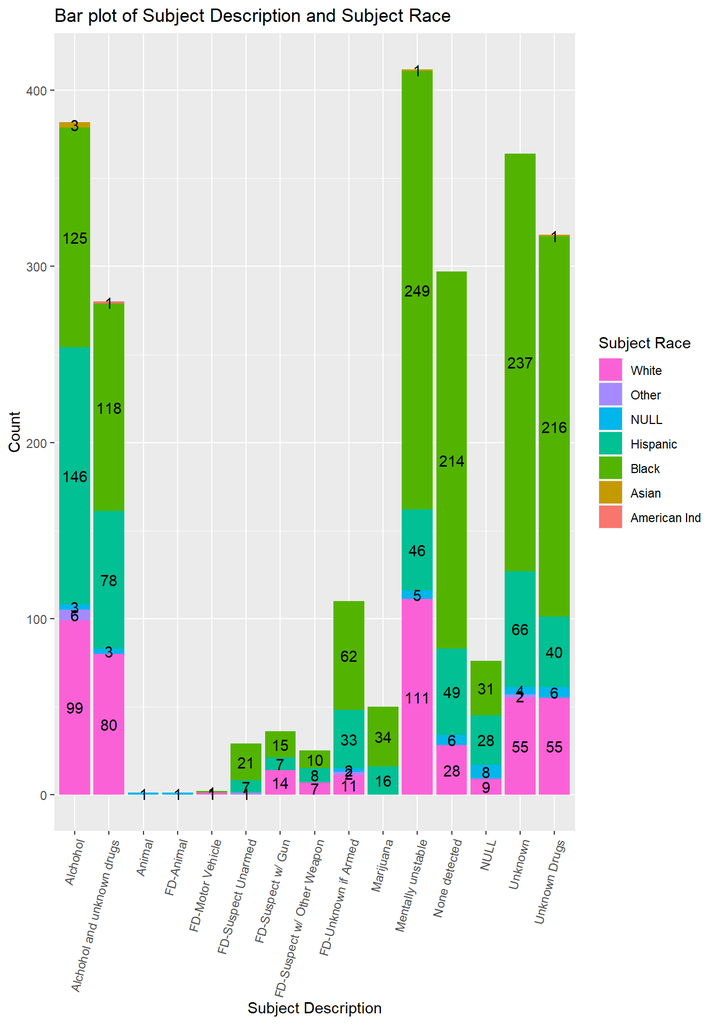

```r
sub_race_dataFrame <- dvDataFrame %>%
  group_by(SUBJECT_DESCRIPTION, SUBJECT_RACE) %>%
  count(name = "count")

sub_df_sorted <- sub_race_dataFrame %>%
  arrange(SUBJECT_RACE, count) %>%
  group_by(SUBJECT_RACE) %>%
  mutate(row = row_number()) %>%
  ungroup()

ggplot(data = sub_df_sorted, aes(x = SUBJECT_DESCRIPTION, y = count, fill = SUBJECT_RACE, order = row)) +
  geom_bar(stat = "identity", position = "stack") +
  scale_fill_discrete(guide = guide_legend(reverse = TRUE)) +
  labs(title = "Bar plot of Subject Description and Subject Race",
       x = "Subject Description",
       y = "Count",
       fill = "Subject Race") +
  theme(axis.text.x = element_text(angle = 75, hjust = 1))+
  geom_text(aes(label = count), position = position_stack(vjust = 0.5))
```

**Correlation between Division and Subject Race**

We will investigate the association between Division and Subject Race using a plot based on best practices in data visualization.

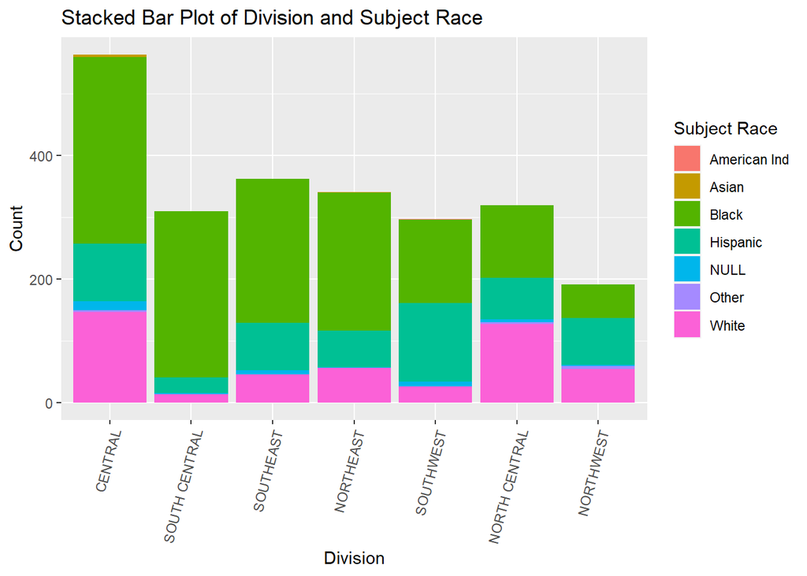

```r
# plot a stacked bar chart
ggplot(count_freq_df, aes(x=DIVISION, y=Freq, fill=SUBJECT_RACE)) +
  geom_bar(stat="identity") +
  labs(title = "Stacked Bar Plot of Division and Subject Race",
       x = "Division",
       y = "Count",
       fill = "Subject Race") +
  theme(axis.text.x = element_text(angle = 75, hjust = 1))
```

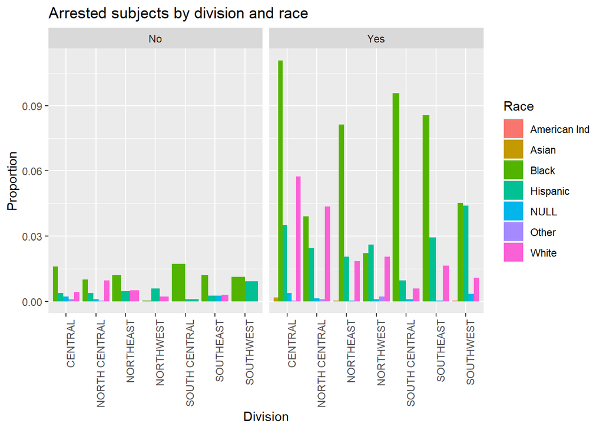

```r
sub_race_dataFrame <- subset(dvDataFrame, select = c(LOCATION_CITY, SUBJECT_RACE, SUBJECT_WAS_ARRESTED))

ggplot(data = dvDataFrame, aes(fill = SUBJECT_RACE,x = DIVISION)) +
  facet_grid(. ~ SUBJECT_WAS_ARRESTED)+
  geom_bar(aes(y =after_stat(count)/sum(after_stat(count))), position = "dodge")+
  theme(axis.text.x = element_text(angle = 90, hjust = 1))  +
  labs(title = "Arrested subjects by division and race",
       x = "Division",
       y = "Proportion",
       fill = "Race")
```

**Corelation among Subject Arrest, Subject race and Subject gender**

Our objective now is to investigate the relationship between three categorical variables - Subject Arrest, Subject Race, and Subject Gender. By analyzing these variables, we can potentially identify any patterns or disparities in arrest rates among different demographic groups. By understanding these relationships, we may be able to uncover insights into potential biases or discrimination in law enforcement practices.

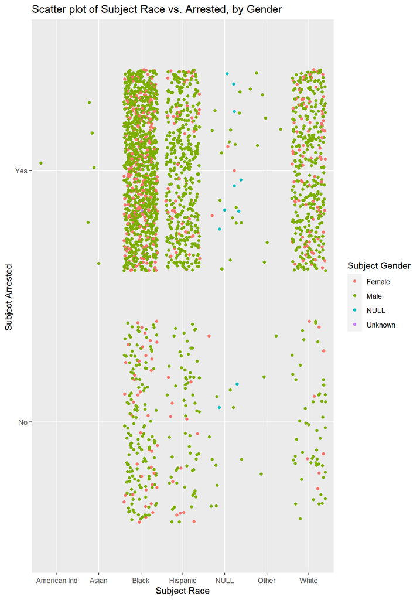

```r
ggplot(dvDataFrame, aes(x =SUBJECT_RACE, color = SUBJECT_GENDER, y = SUBJECT_WAS_ARRESTED))  +
  labs(title = "Scatter plot of Subject Race vs. Arrested, by Gender",
       x = "Subject Race",
       y = "Subject Arrested ",
       color = "Subject Gender")+
  geom_jitter()
```

The scatter plot reveals that male subjects belonging to the black race constitute the majority, followed by those belonging to the Hispanic and white races. Based on this observation, we can infer that male subjects from the black, Hispanic, and white races are more likely to be subjected to ill-treatment. This information provides valuable insight into the prevalence of police brutality among different gender and racial groups.